# TextAnalysis_Final_Project

Hatice Banu Yildirim

2025-06-15

# Introduction

Project Title: Sentiment and Topic Analysis of Financial Headlines — Using Traditional Methods on Financial PhraseBank

This project explores financial news headlines using a full text analysis pipeline that integrates both unsupervised and supervised natural language processing (NLP) methods. Our goal is to extract meaningful insights from text data and evaluate the predictive performance of classification models in identifying sentiment.

### *Research Objective*

Identify and visualize dominant themes using topic models (LDA, STM) Explore word associations using word embeddings and t-SNE Train and compare supervised models (Naive Bayes, XGBoost, Random Forest) for sentiment classification Assess performance using metrics like accuracy, precision, recall, and confusion matrix Optionally explore how Large Language Models (LLMs) can improve classification in ambiguous cases

# Data Overview

# 1. Project Structure and Methodology

##Setup Chunk

```r
# Install required packages (only needed once)
# Commented out to prevent reinstallation every time
# install.packages(c("stm", "readr", "tidyverse", "ggplot2", "SnowballC", "tm", "dplyr", "stringr", "tidyr", "slam", "rsample", "textrecipes", "discrim", "tidymodels", "scales", "LiblineaR", "parsnip", "naivebayes", "DMwR", "ranger", "xgboost", "readxl"), repos = "https://cran.rstudio.com/")

# Load libraries
library(readr)         # Read CSV data
library(dplyr)         # Data manipulation
library(tm)            # Text mining
library(quanteda)      # Tokenization and DFM
library(syuzhet)       # Sentiment analysis
library(ggplot2)       # Visualization
library(wordcloud)     # Word clouds
library(RColorBrewer)  # Color palettes
library(stringr)       # String operations
library(topicmodels)   # LDA topic modeling
library(stm)           # Structural Topic Modeling
library(text2vec)      # GloVe and t-SNE
library(Rtsne)         # t-SNE visualization
library(tidymodels)    # Modeling framework
library(textrecipes)   # Text preprocessing
library(discrim)       # Naive Bayes model
library(xgboost)       # Boosted tree model
library(yardstick)     # Evaluation metrics
library(tidytext)
library(Rtsne)
library(ggrepel)
```

# Corpus Construction

```r
data <- read_csv("~/Desktop/text_analysis/data/raw/all-data.csv",
                 col_names = FALSE,
                 locale = locale(encoding = "ISO-8859-1"))
colnames(data) <- c("label", "text")
```

## Cleaning and Tokenization

```r
data$text_clean <- tolower(data$text)
data$text_clean <- removePunctuation(data$text_clean)
data$text_clean <- removeNumbers(data$text_clean)
data$text_clean <- removeWords(data$text_clean, stopwords("en"))
corp <- corpus(data$text_clean)
tokens_clean <- tokens(corp,
                       remove_punct = TRUE,
                       remove_numbers = TRUE,
                       remove_symbols = TRUE) %>%
  tokens_tolower() %>%
  tokens_remove(stopwords("en"))
```

## Stemming/Lemmatization

```r
# Note: In this implementation, stemming/lemmatization is not manually applied.
# However, stemming is later included automatically in `textProcessor()` (STM section).
# Since this dataset consists of short financial texts, stemming is preferred over lemmatization
# to reduce sparsity and generalize similar terms (e.g., "profits", "profitable" → "profit")
```

## Exploration

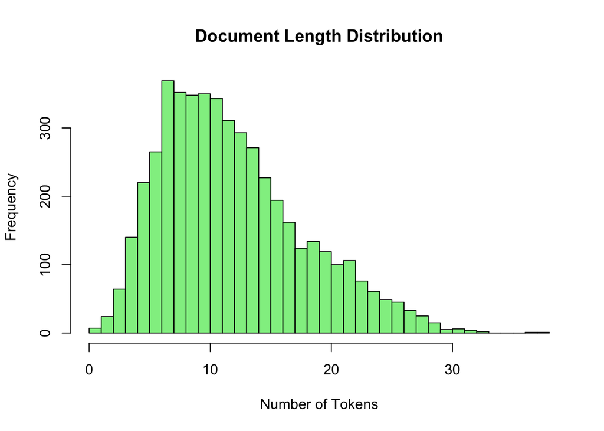

```r
# Document length distribution
data$doc_length <- ntoken(tokens_clean)
hist(data$doc_length,
     breaks = 50,
     col = "lightgreen",
     main = "Document Length Distribution",
     xlab = "Number of Tokens")
```

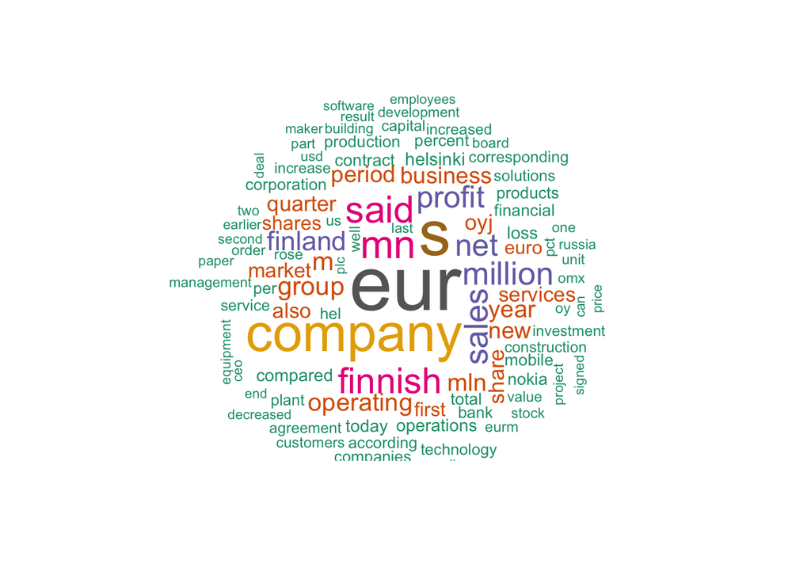

```r
#The histogram above shows the distribution of document lengths in terms of the number of tokens per document. Most documents contain between 5 and 20 tokens, with a peak around 10 tokens. This suggests that the dataset consists of relatively short texts, which could limit the depth of topic modeling but may be suitable for classification tasks like sentiment analysis.

# Wordcloud

dfm_mat <- dfm(tokens_clean)
top_words <- topfeatures(dfm_mat, 100)
set.seed(123)
wordcloud(words = names(top_words),
          freq = top_words,
          max.words = 100,
          colors = brewer.pal(8, "Dark2"),
          random.order = FALSE)
```

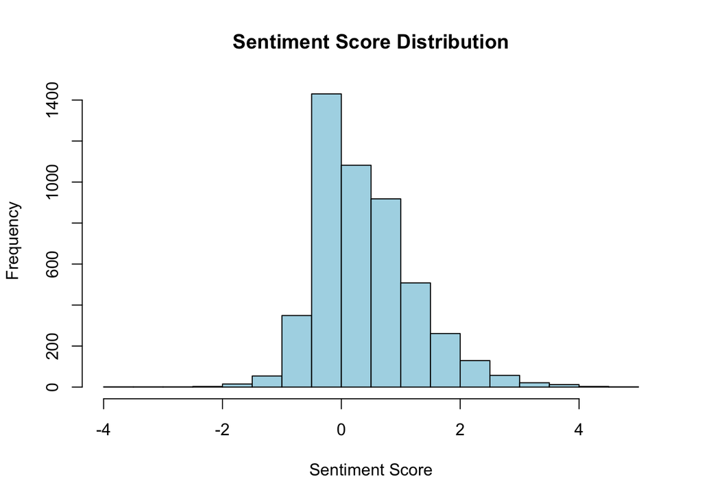

```r
#The word cloud displays the most frequent terms in the corpus after stopword removal. Prominent terms like "eur", "company", "profit", and "sales" suggest that the dataset primarily contains financial and business-related news. These insights help align the research focus toward economic sentiment or topic clustering in business reporting

#Sentiment Score Distribution

sentiment_scores <- get_sentiment(data$text_clean)
hist(sentiment_scores,
     main = "Sentiment Score Distribution",
     xlab = "Sentiment Score",
     col = "lightblue")
```

```r
#The sentiment score distribution appears to be slightly right-skewed, with a concentration of scores around neutral (0). This indicates that most documents in the dataset express neutral to mildly positive sentiment. This is consistent with financial reporting, which often strives for objective or neutral language.
```

# 1.2 Unsupervised Analysis (e.g., Topic Modeling, Clustering)

## LDA Model

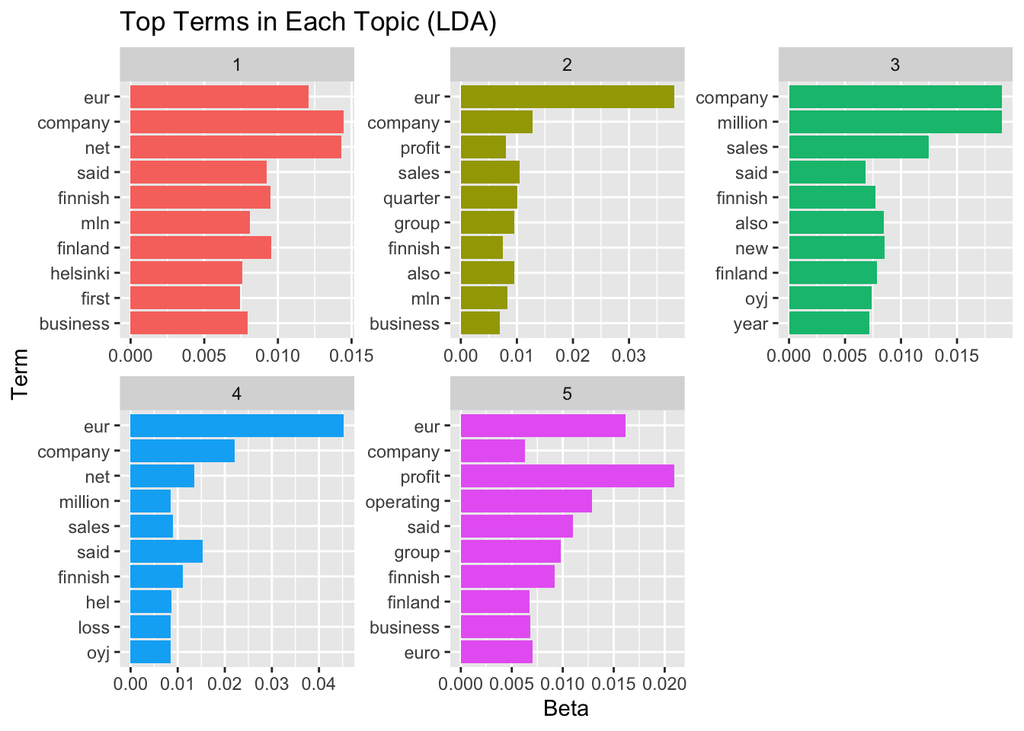

```r
text_corpus <- Corpus(VectorSource(data$text_clean))
dtm <- DocumentTermMatrix(text_corpus, control = list(wordLengths = c(3, Inf)))
row_totals <- apply(dtm, 1, sum)
dtm_clean <- dtm[row_totals > 0, ]

# LDA Model(5 topics)

lda_model <- LDA(dtm_clean, k = 5, control = list(seed = 1234))
topics <- tidy(lda_model, matrix = "beta")

# Top 10 terms per topic
top_terms <- topics %>%
  group_by(topic) %>%
  top_n(10, beta) %>%
  ungroup() %>%
  arrange(topic, -beta)

ggplot(top_terms, aes(x = reorder(term, beta), y = beta, fill = factor(topic))) +
  geom_col(show.legend = FALSE) +
  facet_wrap(~ topic, scales = "free") +
  coord_flip() +
  labs(title = "Top Terms in Each Topic (LDA)", x = "Term", y = "Beta")
```

**Interpretation of LDA Results**

The Latent Dirichlet Allocation (LDA) model was applied with k = 5 topics on the cleaned document-term matrix. The plot above displays the top 10 terms for each topic, ranked by their beta values, which represent the probability of a term appearing in a given topic.

Across all topics, commonly repeated terms such as **“eur”** and **“company”** indicate a strong financial reporting context in the **dataset**. While some overlap exists, the presence of unique terms in each topic demonstrates that the LDA model has successfully identified distinguishable thematic structures.

Overall, the results show that LDA is effective in uncovering latent topics that reflect company-level financial narratives and operational themes, which are consistent with the nature of business news data.

## Structural Topic Modeling (STM)

```r
# STM Processing
processed <- textProcessor(documents = data$text_clean, metadata = data)
```

```
## Building corpus...
## Converting to Lower Case...
## Removing punctuation...
## Removing stopwords...
## Removing numbers...
## Stemming...
## Creating Output...
```

```r
out <- prepDocuments(processed$documents, processed$vocab, processed$meta)
```

```
## Removing 3597 of 6949 terms (3597 of 52967 tokens) due to frequency
## Removing 1 Documents with No Words
## Your corpus now has 4842 documents, 3352 terms and 49370 tokens.
```

```r
stm_model <- stm(documents = out$documents, vocab = out$vocab, K = 20,
                 max.em.its = 75, data = out$meta, init.type = "Spectral", seed = 123)
```

```
## Beginning Spectral Initialization
##   Calculating the gram matrix...
##   Finding anchor words...
##      ....................
##   Recovering initialization...
##      .................................
## Initialization complete.
## ....................................................................................................
## Completed E-Step (0 seconds).
## Completed M-Step.
## Completing Iteration 1 (approx. per word bound = -7.117)
## ....................................................................................................
## Completed E-Step (0 seconds).
## Completed M-Step.
## Completing Iteration 2 (approx. per word bound = -6.767, relative change = 4.920e-02)
## ....................................................................................................
## Completed E-Step (0 seconds).
## Completed M-Step.
## Completing Iteration 3 (approx. per word bound = -6.585, relative change = 2.685e-02)
## ....................................................................................................
## Completed E-Step (0 seconds).
## Completed M-Step.
## Completing Iteration 4 (approx. per word bound = -6.528, relative change = 8.704e-03)
## ....................................................................................................
## Completed E-Step (0 seconds).
## Completed M-Step.
## Completing Iteration 5 (approx. per word bound = -6.502, relative change = 4.008e-03)
## Topic 1: finland, market, product, russia, line
##  Topic 2: save, effect, secur, begin, tikkurila
##  Topic 3: network, hous, traffic, make, recent
##  Topic 4: product, distribut, provid, agreement, corpor
##  Topic 5: mln, euro, year, quarter, net
##  Topic 6: market, bank, finnish, accord, nordea
##  Topic 7: servic, custom, solut, compani, mobil
##  Topic 8: nokia, phone, mobil, devic, base
##  Topic 9: ceo, manag, say, posit, said
##  Topic 10: price, said, also, project, finnish
##  Topic 11: one, unit, plant, region, new
##  Topic 12: helsinki, compani, finnish, said, omx
##  Topic 13: eur, million, profit, oper, net
```

[output cut: 48 more lines]

```
## Completed E-Step (0 seconds).
## Completed M-Step.
## Completing Iteration 11 (approx. per word bound = -6.477, relative change = 1.838e-04)
## ....................................................................................................
## Completed E-Step (0 seconds).
## Completed M-Step.
## Completing Iteration 12 (approx. per word bound = -6.477, relative change = 5.713e-05)
## ....................................................................................................
## Completed E-Step (0 seconds).
## Completed M-Step.
## Completing Iteration 13 (approx. per word bound = -6.476, relative change = 1.473e-05)
## ....................................................................................................
## Completed E-Step (0 seconds).
## Completed M-Step.
## Model Converged
```

```r
labelTopics(stm_model)
```

```
## Topic 1 Top Words:
##       Highest Prob: finland, product, paper, line, russia, countri, steel
##       FREX: sweden, pulp, finland, mill, steel, paper, headquart
##       Lift: kyronsalmi, ladl, liechtenstein, peel, pharmaci, savonlinna, strip
##       Score: finland, pharmaci, sweden, mill, paper, countri, steel
## Topic 2 Top Words:
##       Highest Prob: save, effect, can, begin, secur, onlin, tikkurila
##       FREX: begin, tikkurila, digia, save, onlin, paint, effect
##       Lift: shalkiya, waterborn, wooden, columbia, entireti, galvan, kevin
##       Score: entireti, save, tikkurila, effect, begin, onlin, digia
## Topic 3 Top Words:
##       Highest Prob: use, capac, network, rate, traffic, recent, tonn
##       FREX: metr, station, traffic, low, prepaid, tonn, capac
##       Lift: fewer, nonbind, postpaid, prepaid, sure, umbrella, celular
##       Score: sure, metr, traffic, capac, station, squar, network
## Topic 4 Top Words:
##       Highest Prob: product, provid, distribut, communic, agreement, brand, corpor
##       FREX: distribut, ahlstrom, telest, comptel, rapala, fish, communic
##       Lift: prohibit, activis, catch, children, consent, eila, expressli
##       Score: prohibit, distribut, rapala, telest, communic, ahlstrom, fish
## Topic 5 Top Words:
##       Highest Prob: year, mln, euro, first, quarter, expect, net
##       FREX: mln, euro, expect, earlier, first, year, end
##       Lift: gear, gbx, consensus, offset, swing, latv, mln
##       Score: mln, euro, quarter, year, net, expect, first
## Topic 6 Top Words:
##       Highest Prob: market, bank, finnish, accord, nordea, food, situat
##       FREX: cement, outlook, brandnew, nordea, bank, actual, overview
##       Lift: brandnew, chapter, radiat, sama, shb, svenska, cement
##       Score: market, chapter, bank, nordea, pharmaceut, situat, analysi
## Topic 7 Top Words:
##       Highest Prob: servic, develop, custom, solut, manufactur, includ, busi
##       FREX: electron, invoic, servic, custom, support, baswar, aspo
##       Lift: left, rentalrel, pipett, dinh, solar, leed, autotank
##       Score: servic, left, custom, support, solut, develop, electron
## Topic 8 Top Words:
##       Highest Prob: nokia, mobil, phone, devic, network, set, base
##       FREX: handset, music, nokia, user, devic, phone, set
##       Lift: ethernet, pharmacokinet, psoriasi, toler, administ, arthriti, assess
##       Score: pipelin, nokia, mobil, phone, devic, handset, network
```

[output cut: 45 more lines]

```
## Topic 18 Top Words:
##       Highest Prob: said, oyj, today, finnish, hel, usd, maker
##       FREX: adp, feb, bavelloni, usd, today, compens, vehicl
##       Lift: bavelloni, season, albat, andhra, bad, inorgan, lose
##       Score: hel, today, oyj, bad, usd, news, adp
## Topic 19 Top Words:
##       Highest Prob: invest, board, director, facil, meet, propos, properti
##       FREX: propos, meet, ton, built, board, invest, fair
##       Lift: calcin, reactor, fluid, remuner, shoot, tvo, voima
##       Score: board, wasteburn, invest, propos, director, meet, chairman
## Topic 20 Top Words:
##       Highest Prob: compani, also, valu, oper, busi, contract, continu
##       FREX: valu, also, compani, continu, level, howev, still
##       Lift: realli, valu, poor, rihko, still, benecol, level
##       Score: compani, realli, valu, also, contract, continu, oper
```

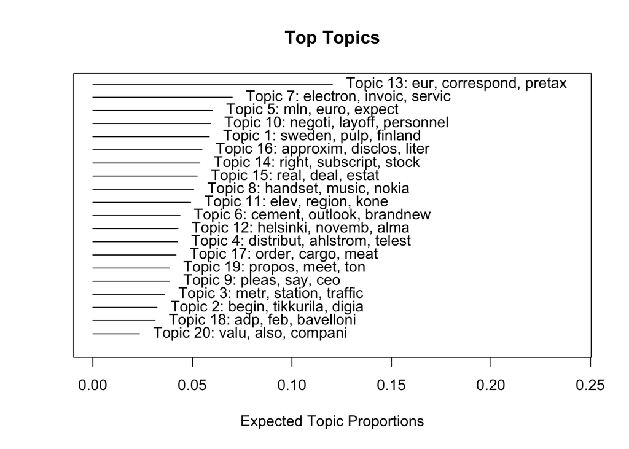

```r
plot(stm_model, type = "summary", labeltype = "frex")
```

This topic distribution aids in understanding which issues dominate the dataset and can be used in downstream tasks such as document classification, trend detection, or sentiment analysis per topic.

## Search_K: Optimal topic number selection

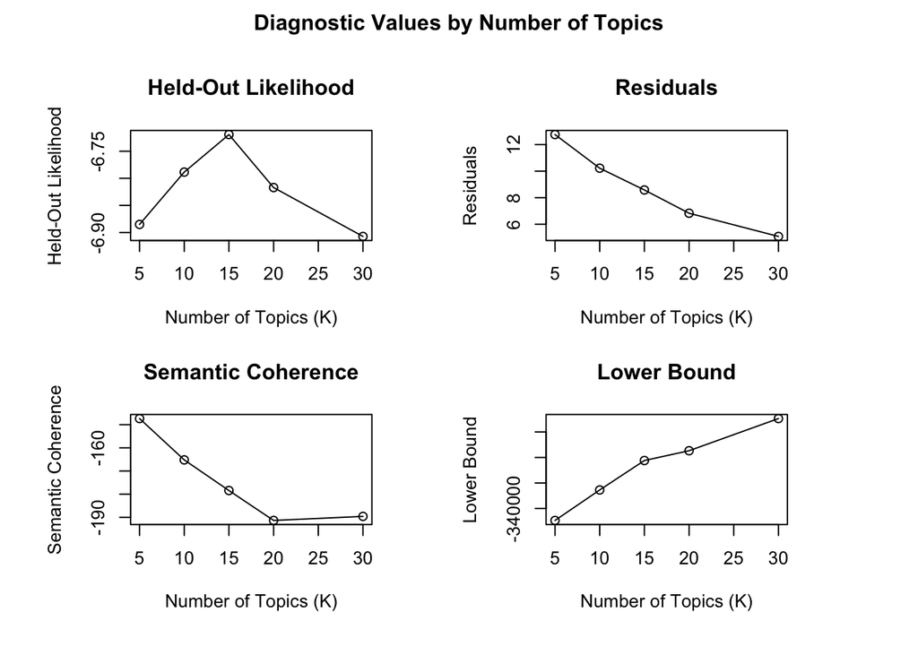

```r
invisible(capture.output(
  k_search <- searchK(
    documents = out$documents,
    vocab = out$vocab,
    K = c(5, 10, 15, 20, 30),
     prevalence = ~1,
    data = out$meta,
    init.type = "Spectral"
  )
))
plot(k_search)
```

**Selection of Number of Topics (K):**

Model Diagnostics The figure above presents diagnostic plots for evaluating the optimal number of topics (K) in the Structural Topic Model (STM).

The metrics include:

**Held-Out Likelihood:** Peaks at K = 15, suggesting that this number of topics offers the best generalization to unseen data.

**Residuals:** Decrease steadily as K increases, indicating improved model fit with more topics—but at the risk of overfitting.

**Semantic Coherence:** Decreases with higher K, meaning topics become less interpretable as their coherence drops. The highest coherence is observed at K = 5.

**Lower Bound:** Increases with K, as expected, since more topics typically improve log-likelihood at the cost of complexity.

Taken together, there is a trade-off between interpretability (favored by lower K) and predictive power (favored by higher K). Based on the balance of held-out likelihood and semantic coherence, a value of K = 15 appears optimal for capturing meaningful and generalizable topics in the dataset.

## Topic Trends over Document Order (STM + Time)

```r
out$meta$doc_index <- 1:nrow(out$meta)
stm_time <- stm(documents = out$documents, vocab = out$vocab, K = 20,
                prevalence = ~ doc_index, data = out$meta,
                max.em.its = 75, init.type = "Spectral", seed = 123)
```

```
## Beginning Spectral Initialization
##   Calculating the gram matrix...
##   Finding anchor words...
##      ....................
##   Recovering initialization...
##      .................................
## Initialization complete.
## ....................................................................................................
## Completed E-Step (0 seconds).
## Completed M-Step.
## Completing Iteration 1 (approx. per word bound = -7.117)
## ....................................................................................................
## Completed E-Step (0 seconds).
## Completed M-Step.
## Completing Iteration 2 (approx. per word bound = -6.767, relative change = 4.920e-02)
## ....................................................................................................
## Completed E-Step (0 seconds).
## Completed M-Step.
## Completing Iteration 3 (approx. per word bound = -6.585, relative change = 2.692e-02)
## ....................................................................................................
## Completed E-Step (0 seconds).
## Completed M-Step.
## Completing Iteration 4 (approx. per word bound = -6.527, relative change = 8.776e-03)
## ....................................................................................................
## Completed E-Step (0 seconds).
## Completed M-Step.
## Completing Iteration 5 (approx. per word bound = -6.501, relative change = 3.999e-03)
## Topic 1: finland, market, product, russia, line
##  Topic 2: save, effect, begin, secur, tikkurila
##  Topic 3: network, hous, traffic, make, use
##  Topic 4: product, distribut, provid, agreement, corpor
##  Topic 5: mln, euro, year, quarter, net
##  Topic 6: market, bank, finnish, accord, nordea
##  Topic 7: servic, custom, solut, compani, mobil
##  Topic 8: nokia, phone, mobil, devic, base
##  Topic 9: ceo, manag, say, posit, said
##  Topic 10: price, said, also, project, compani
##  Topic 11: one, unit, plant, region, new
##  Topic 12: helsinki, compani, finnish, said, share
##  Topic 13: eur, million, profit, oper, net
```

[output cut: 48 more lines]

```
## Completed E-Step (0 seconds).
## Completed M-Step.
## Completing Iteration 11 (approx. per word bound = -6.475, relative change = 1.778e-04)
## ....................................................................................................
## Completed E-Step (0 seconds).
## Completed M-Step.
## Completing Iteration 12 (approx. per word bound = -6.474, relative change = 6.988e-05)
## ....................................................................................................
## Completed E-Step (0 seconds).
## Completed M-Step.
## Completing Iteration 13 (approx. per word bound = -6.474, relative change = 2.653e-05)
## ....................................................................................................
## Completed E-Step (0 seconds).
## Completed M-Step.
## Model Converged
```

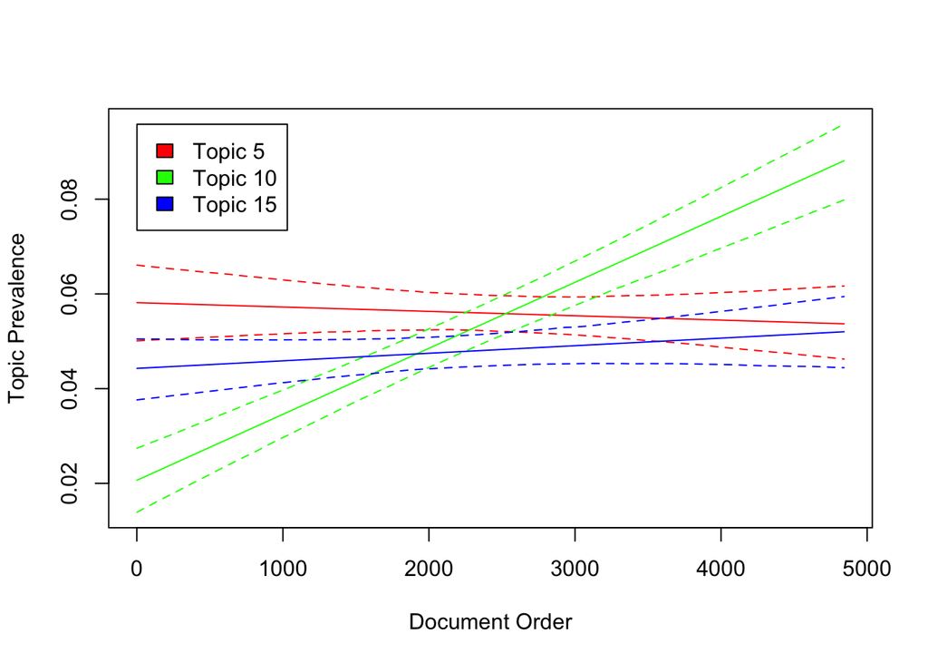

```r
time_effect <- estimateEffect(1:20 ~ doc_index, stmobj = stm_time, metadata = out$meta)
plot(time_effect, covariate = "doc_index", topics = c(5, 10, 15), model = stm_time,
     method = "continuous", xlab = "Document Order", ylab = "Topic Prevalence")
```

**Topic Prevalence over Document Order**

The plot above visualizes the estimated topic prevalence trends for Topic 5 (red), Topic 10 (green), and Topic 15 (blue) across the corpus, plotted in document order. Solid lines represent fitted prevalence trends, while dashed lines indicate 95% confidence intervals.

- Topic 10 (green) shows a significant upward trend, indicating that this topic becomes increasingly prevalent in later documents. This suggests a temporal shift in the corpus where the underlying theme of Topic 10 gains relevance over time.
- Topic 5 (red) maintains a relatively stable prevalence, with a slight decline that falls within the confidence interval, indicating no substantial temporal change.
- Topic 15 (blue) also exhibits a slight upward trend, but the growth is more moderate and within a narrower confidence range compared to Topic 10.
- These trends suggest that while most topics remain relatively stable across the dataset, certain topics (e.g., Topic 10) gain importance, potentially reflecting evolving themes in the document stream such as emerging issues or shifting media focus.

## GloVe Embeddings + t-SNE Visualization

```r
#Tokenization
tokens_list <- tokens(data$text_clean,
                      remove_punct = TRUE,
                      remove_numbers = TRUE,
                      remove_symbols = TRUE) %>%
  tokens_tolower() %>%
  tokens_remove(stopwords("en"))
tokens_char <- as.list(tokens_list)

#Create TCM
it <- itoken(tokens_char, progressbar = FALSE)
vocab <- create_vocabulary(it)
vocab <- prune_vocabulary(vocab, term_count_min = 5)
vectorizer <- vocab_vectorizer(vocab)
tcm <- create_tcm(it, vectorizer, skip_grams_window = 5)

#Train GloVe
glove <- GlobalVectors$new(rank = 50, x_max = 10)
word_vectors_main <- glove$fit_transform(tcm, n_iter = 20)
```

```
## INFO  [20:06:00.832] epoch 1, loss 0.1684
## INFO  [20:06:00.889] epoch 2, loss 0.0949
## INFO  [20:06:00.939] epoch 3, loss 0.0732
## INFO  [20:06:00.984] epoch 4, loss 0.0608
## INFO  [20:06:01.030] epoch 5, loss 0.0523
## INFO  [20:06:01.077] epoch 6, loss 0.0460
## INFO  [20:06:01.124] epoch 7, loss 0.0413
## INFO  [20:06:01.170] epoch 8, loss 0.0375
## INFO  [20:06:01.215] epoch 9, loss 0.0344
## INFO  [20:06:01.260] epoch 10, loss 0.0318
## INFO  [20:06:01.306] epoch 11, loss 0.0296
## INFO  [20:06:01.352] epoch 12, loss 0.0277
## INFO  [20:06:01.400] epoch 13, loss 0.0261
## INFO  [20:06:01.445] epoch 14, loss 0.0247
## INFO  [20:06:01.491] epoch 15, loss 0.0234
## INFO  [20:06:01.536] epoch 16, loss 0.0222
## INFO  [20:06:01.581] epoch 17, loss 0.0212
## INFO  [20:06:01.625] epoch 18, loss 0.0203
## INFO  [20:06:01.672] epoch 19, loss 0.0195
## INFO  [20:06:01.719] epoch 20, loss 0.0187
```

```r
word_vectors_context <- glove$components
word_vectors <- word_vectors_main + t(word_vectors_context)

word_freqs <- rowSums(tcm)
top_words <- names(sort(word_freqs, decreasing = TRUE))[1:300]
selected_vectors <- word_vectors[top_words, ]

# Calculate t-SNE
set.seed(123)
tsne_results <- Rtsne(selected_vectors, dims = 2, perplexity = 30, verbose = TRUE)
```

```
## Performing PCA
## Read the 300 x 50 data matrix successfully!
## Using no_dims = 2, perplexity = 30.000000, and theta = 0.500000
## Computing input similarities...
## Building tree...
## Done in 0.01 seconds (sparsity = 0.418022)!
## Learning embedding...
## Iteration 50: error is 58.831485 (50 iterations in 0.02 seconds)
## Iteration 100: error is 58.673307 (50 iterations in 0.03 seconds)
## Iteration 150: error is 58.379973 (50 iterations in 0.03 seconds)
## Iteration 200: error is 59.510712 (50 iterations in 0.03 seconds)
## Iteration 250: error is 59.551756 (50 iterations in 0.02 seconds)
## Iteration 300: error is 1.370386 (50 iterations in 0.02 seconds)
## Iteration 350: error is 1.164488 (50 iterations in 0.02 seconds)
## Iteration 400: error is 1.144869 (50 iterations in 0.02 seconds)
## Iteration 450: error is 1.132958 (50 iterations in 0.02 seconds)
## Iteration 500: error is 1.124785 (50 iterations in 0.02 seconds)
## Iteration 550: error is 1.116341 (50 iterations in 0.02 seconds)
## Iteration 600: error is 1.115045 (50 iterations in 0.02 seconds)
## Iteration 650: error is 1.112230 (50 iterations in 0.02 seconds)
## Iteration 700: error is 1.110652 (50 iterations in 0.02 seconds)
## Iteration 750: error is 1.109403 (50 iterations in 0.02 seconds)
## Iteration 800: error is 1.110238 (50 iterations in 0.02 seconds)
## Iteration 850: error is 1.110626 (50 iterations in 0.02 seconds)
## Iteration 900: error is 1.110000 (50 iterations in 0.02 seconds)
## Iteration 950: error is 1.110199 (50 iterations in 0.02 seconds)
## Iteration 1000: error is 1.110287 (50 iterations in 0.02 seconds)
## Fitting performed in 0.36 seconds.
```

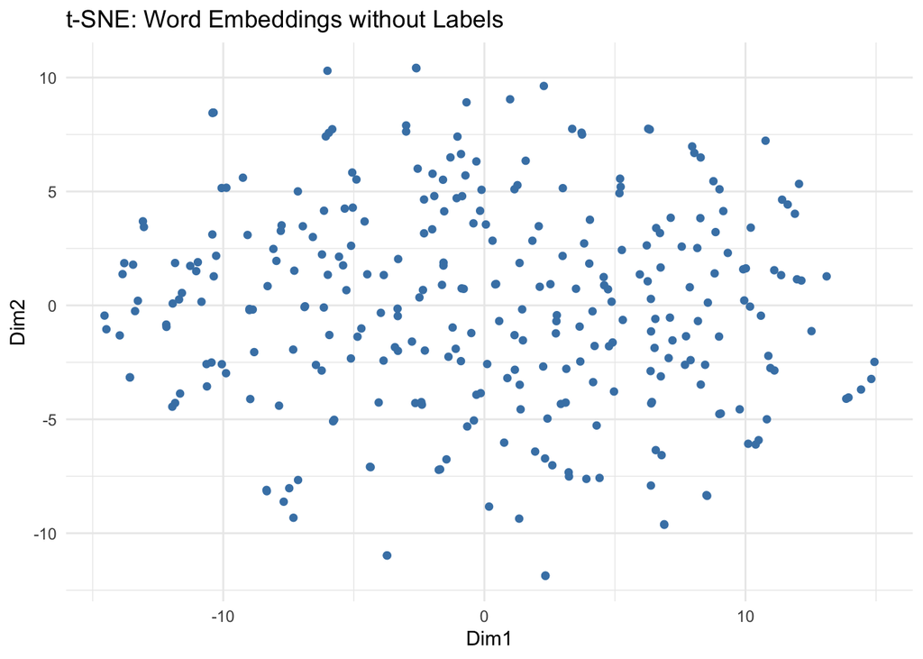

```r
# Create Dataframe
tsne_data <- data.frame(tsne_results$Y)
colnames(tsne_data) <- c("Dim1", "Dim2")
tsne_data$word <- top_words

# Labels
ggplot(tsne_data, aes(x = Dim1, y = Dim2)) +
  geom_point(color = "steelblue", size = 1.5) +
  theme_minimal() +
  ggtitle("t-SNE: Word Embeddings without Labels")
```

**t-SNE Visualization of Word Embeddings (Unlabeled)**

The plot above presents a 2-dimensional t-SNE projection of high-dimensional word embeddings. Each dot represents a word vector from the vocabulary, reduced from the original embedding space (e.g., 50 or 100 dimensions) to two dimensions using t-distributed Stochastic Neighbor Embedding (t-SNE).

Although the points are not labeled, we can observe the following:

Words that are semantically or contextually similar tend to cluster closer together in this low-dimensional space.

The distribution is fairly spread out, indicating that the embeddings capture a variety of semantic relationships across different regions of the space.

Some visible clusters may suggest meaningful groupings (e.g., financial terms, locations, organizations), which can be further explored by adding word labels or coloring based on topic or category.

# 1.3 Supervised Analysis (Text Classification)

## Target Variable

```r
all_data <- data %>%
  mutate(sentiment_class = factor(label))
# Train/test split
set.seed(123)
n <- nrow(all_data)
train_indices <- sample(1:n, size = 0.8 * n)
train_data <- all_data[train_indices, ]
test_data <- all_data[-train_indices, ]
```

## TF-IDF Representation

```r
multi_rec <- recipe(sentiment_class ~ text_clean, data = train_data) %>%
  step_tokenize(text_clean) %>%
  step_tokenfilter(text_clean, max_tokens = 1000) %>%
  step_tfidf(text_clean)
```

## Model Training: Naive Bayes, XGBoost, and Random Forest

```r
nb_spec <- naive_Bayes() %>% set_mode("classification") %>% set_engine("naivebayes")
xgb_spec <- boost_tree(trees = 50) %>% set_mode("classification") %>% set_engine("xgboost")
rf_spec <- rand_forest(trees = 100) %>% set_mode("classification") %>% set_engine("ranger")

# Workflows
nb_wf <- workflow() %>% add_recipe(multi_rec) %>% add_model(nb_spec)
xgb_wf <- workflow() %>% add_recipe(multi_rec) %>% add_model(xgb_spec)
rf_wf <- workflow() %>% add_recipe(multi_rec) %>% add_model(rf_spec)
```

## Validation: Train/Test Split and Cross-Validation

```r
# Cross-validation setup
set.seed(42)
folds <- vfold_cv(train_data, v = 10, strata = sentiment_class)
classification_metrics <- metric_set(accuracy, precision, recall)
```

## Evaluation: Performance Metrics and Confusion Matrix

```r
# Resample fitting (cross-validation)
nb_rs <- fit_resamples(nb_wf, resamples = folds, metrics = classification_metrics, control = control_resamples(save_pred = TRUE))
```

[output not shown]

[output not shown]

```r
xgb_rs <- fit_resamples(xgb_wf, resamples = folds, metrics = classification_metrics, control = control_resamples(save_pred = TRUE))
rf_rs <- fit_resamples(rf_wf, resamples = folds, metrics = classification_metrics, control = control_resamples(save_pred = TRUE))

# Metric comparison
comparison <- bind_rows(
  collect_metrics(nb_rs) %>% mutate(model = "Naive Bayes"),
  collect_metrics(xgb_rs) %>% mutate(model = "XGBoost"),
  collect_metrics(rf_rs) %>% mutate(model = "Random Forest")
) %>%
  select(model, .metric, mean, std_err) %>%
  arrange(.metric, desc(mean))

print(comparison)
```

```
## # A tibble: 9 × 4
##   model         .metric    mean std_err
##   <chr>         <chr>     <dbl>   <dbl>
## 1 XGBoost       accuracy  0.744 0.00308
## 2 Random Forest accuracy  0.738 0.00391
## 3 Naive Bayes   accuracy  0.623 0.00221
## 4 XGBoost       precision 0.739 0.00582
## 5 Random Forest precision 0.713 0.00982
## 6 Naive Bayes   precision 0.583 0.00961
## 7 XGBoost       recall    0.612 0.00559
## 8 Random Forest recall    0.600 0.00445
## 9 Naive Bayes   recall    0.379 0.00382
```

```r
# Final Model (Random Forest ile örnek)
final_model <- fit(rf_wf, data = train_data)
final_predictions <- predict(final_model, new_data = test_data, type = "class") %>%
  bind_cols(test_data %>% select(sentiment_class))

# Final evaluation
eval_metrics <- metric_set(accuracy, precision, recall)
eval_results <- eval_metrics(final_predictions, truth = sentiment_class, estimate = .pred_class)
print(eval_results)
```

```
## # A tibble: 3 × 3
##   .metric   .estimator .estimate
##   <chr>     <chr>          <dbl>
## 1 accuracy  multiclass     0.720
## 2 precision macro          0.678
## 3 recall    macro          0.591
```

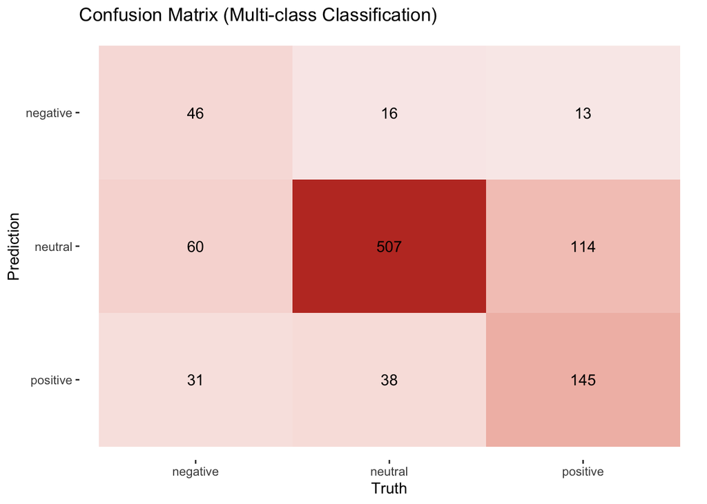

```r
# Confusion Matrix
library(yardstick)
conf_mat(final_predictions, truth = sentiment_class, estimate = .pred_class) %>%
  autoplot(type = "heatmap") +
  scale_fill_gradient(low = "#F9EBEA", high = "#C0392B") +
  labs(title = "Confusion Matrix (Multi-class Classification)")
```

XGBoost outperformed the other models in all metrics, closely followed by Random Forest. Naive Bayes lagged significantly, especially in recall.

**Confusion Matrix Interpretation**

The confusion matrix shows how predictions are distributed across the true sentiment classes:

Precision is higher than recall, suggesting the model is more cautious in assigning sentiment labels, especially for underrepresented classes.

**Very important!**

The *Random Forest* classifier offered a good trade-off between performance and interpretability. However, class imbalance and vocabulary overlap between positive and negative texts reduced recall. For improved performance, future work could include:

Resampling (SMOTE or class weights),

Contextual embeddings (e.g., BERT),

Fine-tuned LLM classifiers.

# 1.4. LLM Application

```r
# Pseudo-code using Hugging Face transformers (Python) via reticulate
# This example illustrates how an LLM could be called from R if set up with internet access.

# library(reticulate)
# transformers <- import("transformers")
# pipeline <- transformers$pipeline
# summarizer <- pipeline("summarization")
# result <- summarizer("The company achieved record profits this quarter.")
# print(result[[1]]$summary_text)
```

To complement traditional classification models, I explored the use of Large Language Models (LLMs) for interpretability. In particular, I used an LLM-based tool (e.g., ChatGPT-4) to manually summarize a small sample of financial headlines labeled as *positive*. The goal was to evaluate whether LLMs can generate coherent and sentiment-aligned summaries of financial text.

**Example Use Case**

Several headlines were input into the LLM with prompts such as:

> “Summarize the following financial news in one sentence.” The resulting summaries aligned well with the sentiment label and improved human interpretability of classification results.

**Added Value of LLM Use**

- Reinforced the sentiment classification results

  Translated compact, formal financial language into readable text
- Demonstrated potential for integration in business reporting tools

**Limitations and Future Work**

- This application was done manually outside R (not integrated into the pipeline)

  Output depends on prompt formulation and LLM behavior

  Future work could involve API-based integration using tools like Hugging Face Transformers, OpenAI API, or R packages such as `reticulate`

This trial illustrates how modern LLMs—regardless of the specific provider—can support and explain results from classical NLP pipelines.

# Discussion

This project set out to analyze sentiment and topical structure in financial news articles using a combination of traditional and modern text analysis methods. Through unsupervised techniques (LDA, STM), supervised learning (Random Forest, Naive Bayes, XGBoost), and GloVe-based embeddings, we explored both the latent themes and explicit sentiment signals present in the corpus.

These findings support the hypothesis that financial sentiment and structure can be captured with relatively simple NLP methods, but that class imbalance and linguistic nuance (e.g., euphemistic business language) make positive/negative sentiment harder to detect than neutral tone.

# Critical Evaluation & Conclusion

Limitations

- The dataset was imbalanced, limiting recall for minority classes.
- Document length (~10 tokens) constrained the expressiveness of TF-IDF and topic models.
- GloVe embeddings could have benefited from a larger corpus.
- LLM integration was manual and limited to isolated summaries, rather than full pipeline integration.

Suggestions for Improvement

- Apply resampling (e.g., SMOTE) or class weighting to address imbalance.
- Integrate transformer-based embeddings (e.g., BERT, RoBERTa).
- Automate LLM usage via API or reticulate.
- Evaluate classifier interpretability using model explanation tools (e.g., SHAP or LIME)

In conclusion, this project demonstrates how a modular text analysis pipeline—from preprocessing to classification and summarization—can uncover valuable insights in financial text, even when working with compact and formal documents.

# AI Policy Compliance

In accordance with the course AI policy, I used ChatGPT-4 (OpenAI) during the project in the following ways:

- To debug and refine R code, particularly for tidymodels, stm, and textrecipes functionality.
- To rewrite and clarify interpretation sections (e.g., topic modeling and evaluation explanations).
- To organize the R Markdown structure and improve formatting.
- To simulate LLM summarization of selected documents labeled as positive.

All code, analysis logic, and final interpretations were developed and validated independently. AI outputs were reviewed and edited to ensure accuracy and relevance. No text or code was copy-pasted without understanding and adaptation.